# R语言入门

# 1 R的安装与下载

[R官方下载网站:http://www.r-project.org](http://www.r-project.org)

打开网页点击download R，然后选择适合自己电脑系统的R语言版本，安装过程中建议初学者可选择R语言的中文版本进行选择安装，逐渐培养兴趣。

安装下载具体操作如下所示：

**Step1:download R**

[figure not shown]

**Step2:select R**

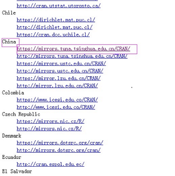

**Step3:选择配置系统的R**

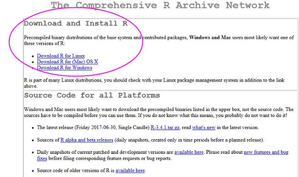

**Step4:选择最新版本R**

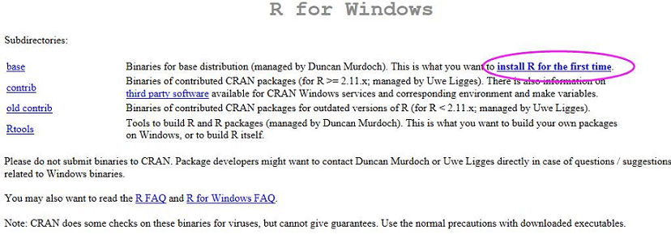

**Step5:下载Windows的R**

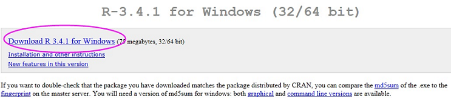

# 2 R菜单简介

启动R语言之后，显示R语言窗口如下图所示：

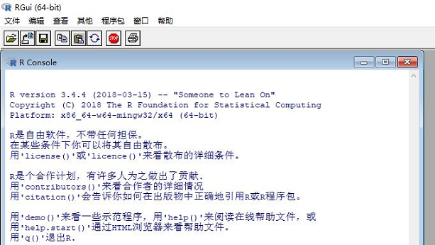

注：菜单栏可选中英文状态。

**文件菜单**：主要用于R程序的新建、打开、打印和保存，R工作空间的管理等。

**编辑菜单**：主要服务于R程序的编写以及R控制台清空管理。

**查看菜单**：指定在主窗口中是否显示状态栏，是否显示工具栏

**其它菜单**：主要用于终止当前或所有运算，显示或删除工作空间中包含的R对象，显示当前已经加载的包名称列表等。

**程序包菜单**：主要用于加载已下载的包。联网条件下，指定镜像地址，下载安装其它包，对已下载的包进行更新等。

**窗口菜单**：主要用于指定R主窗口中所包含的其它窗口，设置排列方式等。

**帮助菜单**：主要用于以各种方式浏览R的帮助文档。

注：在菜单栏目的文件下，新建程序脚本，打开R的编辑器，可以直接进行代码的书写，当代码写完后，选中所写代码，用键盘组合快捷键ctrl+R运行。

[figure not shown]

# 3 R功能键

R的功能键，在不同的系统下不同，以windows系统、mac系统下安装的R在使用功能键进行操作，如下所示：

| 功能 | Windows & Linux | Mac |
| --- | --- | --- |
| 控制台清屏 | Ctrl+L | Command+L |
| 打开文档 | Ctrl+O | Command+O |
| 历史记录翻滚 | Up/Down | Up/Down |
| 移动鼠标至本行的最后一个字 | End | Command+Right |
| 运行光标所在行代码或者当前选中行的代码 | Ctrl+R | Command+R |
| 保存当前文档 | Ctrl+S | Command+S |
| 新编辑器 | Ctrl+Shift+N | Command+Shift+N |
| Cut | Ctrl+X | Command+X |
| Copy | Ctrl+C | Command+C |
| Paste | Ctrl+V | Command+V |
| Select All | Ctrl+A | Command+A |
| 运行当前行 | Ctrl+Enter | Command+Enter |